```python
import pandas as pd
pd.set_option('display.expand_frame_repr', False)

import matplotlib
import matplotlib.pyplot as plt
font = {'size' : 20}
matplotlib.rc('font', **font)

from pylab import rcParams
rcParams["figure.figsize"] = 30,16

import seaborn as sns

from statsmodels.tsa.statespace.sarimax import SARIMAX
from pmdarima.arima import auto_arima

from collections import OrderedDict

import datetime as dt
from datetime import timedelta, date

from sklearn.preprocessing import MinMaxScaler
import joblib

import warnings
warnings.filterwarnings("ignore")

import sys
sys.path.insert(0, "../")
import functions
```

```python
#Unskalierte Daten für Analysen laden
df_unscaled = pd.read_csv("../3-Data Preparation/data.csv", index_col=0, parse_dates=True)
df_unscaled.index.freq = "D"

#Wahre Werte der Testdaten
y_true = df_unscaled["verbrauch"]["2021-01-01":]

#Skalierte Daten für Modellierung laden
df_scaled = pd.read_csv("../3-Data Preparation/arima_data_scaled.csv", index_col=0, parse_dates=True)
df_scaled.index.freq = "D"

#Aufteilung in endogene und exogene Daten
exog_train = df_scaled[["arbeitstag", "temperatur"]][:"2020-12-31"]
exog_test = df_scaled[["arbeitstag", "temperatur"]]["2021-01-01":]

exog = exog_train.append(exog_test)

endog_train = df_scaled["verbrauch"][:"2020-12-31"]
endog_test = df_scaled["verbrauch"]["2021-01-01":]

endog = endog_train.append(endog_test)
```

# Zwischenfazit zu ARIMA

Im Folgenden wird das ARIMA-Modell bewertet und mit der Baseline verglichen.

## ARIMA(2,0,2)(2,0,2)7 [Arbeitstag, Temperatur]

Das ARIMA(2,0,2)(2,0,2)7 [Arbeitstag, Temperatur] kann die Zeitreihe (auch durch Modifikation der Arbeitstage) sehr gut abbilden. Es erreicht einen MAPE von 2,1%, eine Log-Likelihood von 4.557 und ein AIC von -9.092. Das Modell erfüllt damit das Erfolgskriterium und kann die Baseline schlagen. Das Modell kann die jährliche und wöchentliche Saisonalität gut abbilden. Feiertage und vor Allem die Weihnachtsfeiertage führen allerdings zu starken Verzerrungen und können nur sehr schlecht vorhergesagt werden.

```python
#Nicht-saisonale und saisonale Ordnung festlegen
order = (2, 0, 2) #p, d, q
seasonal_order = (2, 0, 2, 7) #P, D, Q, m

#Modell mit Trainingsdaten erstellen
train_model_config = SARIMAX(endog=endog_train, exog=exog_train, order=order, seasonal_order=seasonal_order)
train_model = train_model_config.fit()

#Modell mit allen Daten erstllen und Konfiguration/Koeffizienten von ersten Modell übernehmen (kein neues Training)
model_config = SARIMAX(endog=endog, exog=exog, order=order, seasonal_order=seasonal_order)
model = model_config.filter(train_model.params)

#Modell ausgeben
print(model.summary())
print()
```

```
                                     SARIMAX Results
=========================================================================================
Dep. Variable:                         verbrauch   No. Observations:                 2557
Model:             SARIMAX(2, 0, 2)x(2, 0, 2, 7)   Log Likelihood                4556.901
Date:                           Fri, 04 Feb 2022   AIC                          -9091.801
Time:                                   12:27:35   BIC                          -9027.489
Sample:                               01-01-2015   HQIC                         -9068.479
                                    - 12-31-2021
Covariance Type:                             opg
==============================================================================
                 coef    std err          z      P>|z|      [0.025      0.975]
------------------------------------------------------------------------------
arbeitstag     0.2951      0.002    151.520      0.000       0.291       0.299
temperatur    -0.0734      0.014     -5.418      0.000      -0.100      -0.047
ar.L1          1.1178      0.102     10.921      0.000       0.917       1.318
ar.L2         -0.1766      0.091     -1.950      0.051      -0.354       0.001
ma.L1         -0.2569      0.103     -2.486      0.013      -0.459      -0.054
ma.L2         -0.1455      0.015     -9.447      0.000      -0.176      -0.115
ar.S.L7        0.1746      0.638      0.274      0.784      -1.076       1.425
ar.S.L14       0.8174      0.635      1.287      0.198      -0.428       2.062
ma.S.L7       -0.0991      0.631     -0.157      0.875      -1.335       1.137
ma.S.L14      -0.7655      0.581     -1.317      0.188      -1.905       0.374
sigma2         0.0017   2.85e-05     59.953      0.000       0.002       0.002
===================================================================================
Ljung-Box (L1) (Q):                   0.03   Jarque-Bera (JB):              3671.53
Prob(Q):                              0.85   Prob(JB):                         0.00
Heteroskedasticity (H):               0.91   Skew:                            -0.16
Prob(H) (two-sided):                  0.17   Kurtosis:                         8.86
===================================================================================

Warnings:
[1] Covariance matrix calculated using the outer product of gradients (complex-step).
```

```
      Vorhersage
R2          0.96
MAE       3613.0
MSE   26901261.0
RMSE      5187.0

MAPE       2.1 %
```

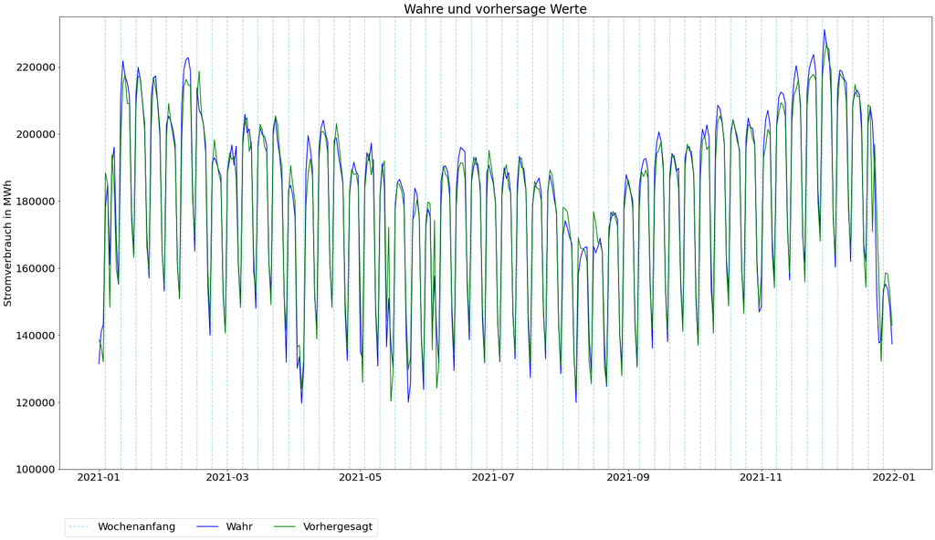

```python
#Vorhersage erzeugen
scaled_preds = model.predict(start="2021-01-01", end="2021-12-31", dynamic=False).values

#Vorhersagen mit echten Werten vergleichen
functions.custom_metrics_arima(y_true, scaled_preds, plot=True)
```

### Modell speichern

Das Modell wird im pkl-Format gespeichert.

```python
model.save("Modelle/arima.pkl")

#from statsmodels.tsa.statespace.sarimax import SARIMAXResults
#new_model = SARIMAXResults.load("Modelle/arima.pkl")
```

# Vergleich mit Baseline

Im Vergleich zu Baseline sind die Vorhersagen des Modells etwas besser, da vor Allem die wöchentliche Saisonalität etwas besser abgebildet werden kann. An Feiertagen und um die Weihnachtsfeiertage herum kommt es bei beiden Modellen zu starken Abweichungen, allerdings ist die Baseline hier etwas zuverlässiger. Das Erfolgskriterium eines MAPE von 2,2% wird erfüllt.

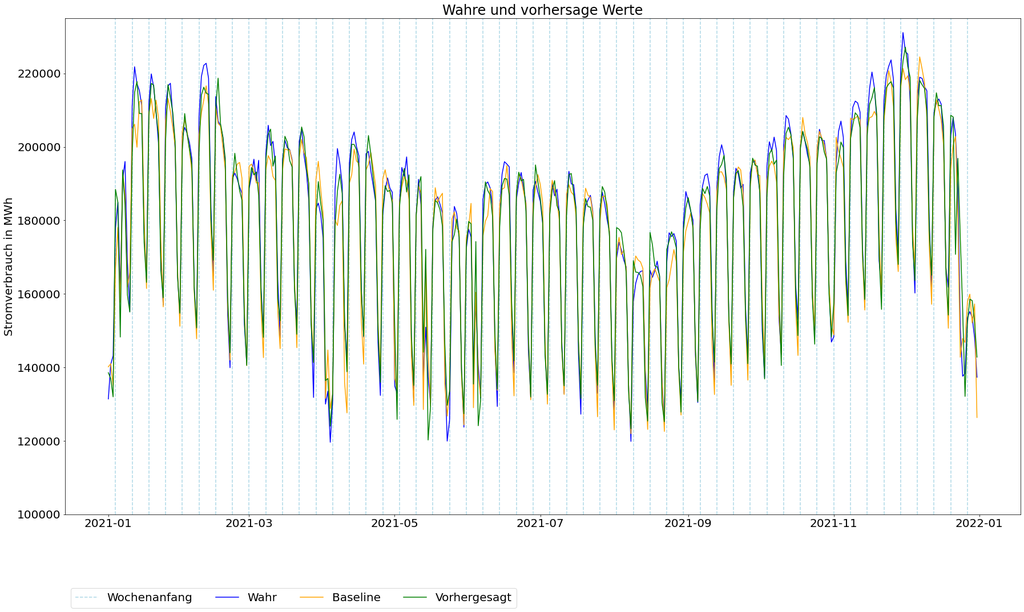

```python
df_baseline = pd.read_csv("../1-Business Understanding/data_baseline.csv", index_col=0, parse_dates=True)["2021-01-01":]

scaler_target = joblib.load("../3-Data Preparation/scaler_endog.save")
arima_preds = pd.DataFrame(data=scaler_target.inverse_transform(scaled_preds.reshape(-1, 1)), columns=["vorhergesagt"], index=pd.date_range('01/01/2021', periods=365, freq='D')).squeeze()

for date in y_true[y_true.index.weekday == 0].index:

    plt.axvline(x=date, ymin=0, ymax=1, color="lightblue", linestyle="--", label="Wochenanfang")

plt.plot(y_true, color="blue", label="Wahr");
plt.plot(df_baseline, color="orange", label="Baseline");
plt.plot(arima_preds, color="green", label="Vorhergesagt");
plt.title("Wahre und vorhersage Werte")
plt.ylabel("Stromverbrauch in MWh")
plt.ylim(100000,235000)
plt.legend(loc="upper right")

#Legende einfügen
handles, labels = plt.gca().get_legend_handles_labels()
by_label = OrderedDict(zip(labels, handles))
plt.legend(by_label.values(), by_label.keys(), loc="lower left", bbox_to_anchor=(0,-0.2), ncol=5)

plt.show()
```

```python
print("Vorhersage:")
functions.custom_metrics(y_true, arima_preds, statistics=True, plot=False)

print("-------------------------------------------------------------------------------------------------")
print("Baseline:")
functions.custom_metrics(y_true, df_baseline, statistics=True, plot=False)
```

```
Vorhersage:
      Vorhersage
R2           1.0
MAE       3612.6
MSE   26901261.2
RMSE      5186.6

MAPE       2.1 %
-------------------------------------------------------------------------------------------------
Baseline:
      Vorhersage
R2           1.0
MAE       4271.2
MSE   29925346.3
RMSE      5470.4

MAPE       2.4 %
```

Bei den Residuen zeigt sich, dass die Abweichungen von ARIMA häufig unter den Abweichungen der Baseline und auch unter der akzeptierten Abweichung von 2,2% liegen. Wie bereits beschrieben, kommt es an Feiertagen zu größeren Abweichungen bei beiden Modellen, allerdings ist die Baseline hier etwas besser An den Weihnachtsfeiertagen kommt es zu erheblichen Abweichungen bei ARIMA, wohingegen die Baseline etwas genauer ist.

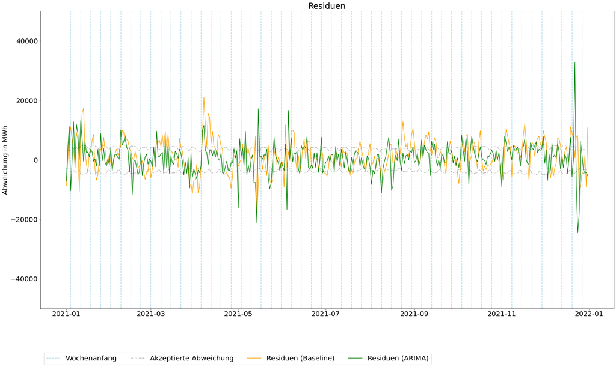

```python
for date in y_true[y_true.index.weekday == 0].index:

    plt.axvline(x=date, ymin=0, ymax=1, color="lightblue", linestyle="--", label="Wochenanfang")

resids_preds = y_true - arima_preds
resids_baseline = y_true - df_baseline["vorhergesagter verbrauch"]["2021-01-01":]

y_upper_deviation = y_true * 0.022
y_lower_deviation = y_upper_deviation * -1

plt.plot(y_upper_deviation, color="grey", linestyle=":", linewidth=1.5, label="Akzeptierte Abweichung")
plt.plot(y_lower_deviation, color="grey", linestyle=":", linewidth=1.5)

plt.plot(resids_baseline, color="orange", label="Residuen (Baseline)")
plt.plot(resids_preds, color="green", label="Residuen (ARIMA)")
plt.ylabel("Abweichung in MWh")
plt.ylim(-50000, 50000)
plt.title("Residuen")

#Legende einfügen
handles, labels = plt.gca().get_legend_handles_labels()
by_label = OrderedDict(zip(labels, handles))
plt.legend(by_label.values(), by_label.keys(), loc="lower left", bbox_to_anchor=(0,-0.2), ncol=5)

plt.show()
```